# ESIEE-Paris: 2025 - 2026

Assia Loubane & Alexandre Coulibaly

2026-02-22

Fouille de données avec R pour la data science et l’intelligence artificielle\ Projet final : Détection de texte généré par IA (LLM Detect)

Assia Loubane — Alexandre Coulibaly\ ESIEE Paris

# 1 Introduction

La montée en puissance des **Large Language Models (LLM)** permet de générer des textes très proches de l’écriture humaine, ce qui motive le développement de méthodes fiables de **détection de contenu généré**. L’ensemble de données permettant de détecter le texte généré par l’IA constitue un défi intéressant pour la classification bayésienne et l’analyse factorielle discriminante.

L’objectif de ce projet est de comparer plusieurs pipelines de classification pour distinguer des textes **humains** et **générés par IA** :

- **Stylométrie et caractéristiques linguistiques** (statistiques d’écriture)
- **TF‑IDF** (n‑grams lexicaux)
- **Réduction de dimension** (SVD)
- **Analyse discriminante** (AFD / LDA)
- **Classifieurs probabilistes** (Naive Bayes, régression logistique ridge)

Nous évaluons aussi la **généralisation inter‑dataset** : entraînement sur DAIGT et test sur LLM Detect.

# 2 Données

Deux datasets sont utilisés :

- **DAIGT Proper Train Dataset** : datasets d’entraînement (text, label, source, fold).
- **LLM Detect AI Generated Text** : dataset Kaggle (train_essays / test_essays).

Le dataset DAIGT est ajouté pour **compenser le manque de données d’entraînement** dans la compétition, et stabiliser l’apprentissage.

# 3 Méthodes

Une étape d’analyse exploratoire (EDA) nous a permis d’examiner les propriétés statistiques des textes pour nous guider dans le choix des représentations et des modèles de classification.

## 3.1 Pipeline A — Stylométrie + AFD (LDA) + Naive Bayes (CV)

Extraction de caractéristiques simples : longueurs de mots/phrases, diversité lexicale, ponctuation, majuscules.  
Réduction par **AFD/LDA** puis classification avec **Naive Bayes**.

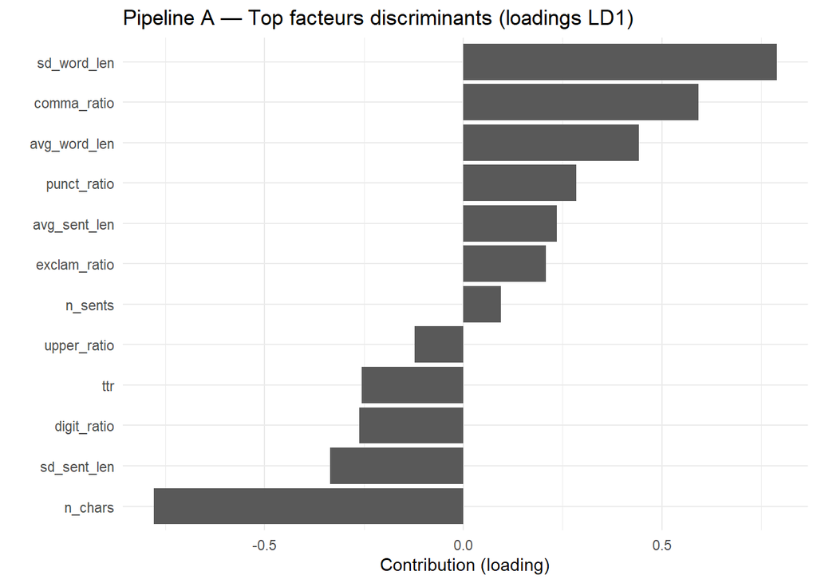

```r
load(here::here("stylometrie.RData"))

topL <- head(lda_loadings_A, 12)
ggplot(topL, aes(x = reorder(feature, loading), y = loading)) +
  geom_col() +
  coord_flip() +
  theme_minimal() +
  labs(title = "Pipeline A — Top facteurs discriminants (loadings LD1)",
       x = "", y = "Contribution (loading)")
```

On ajuste une AFD sur l’échantillon complet afin d’obtenir des loadings stables: les performances sont évaluées séparément via CV.

## 3.2 Pipeline B — TF‑IDF + Ridge Logistic Regression (CV)

Représentation des textes par **TF‑IDF** (n‑grams de mots), puis classification avec **régression logistique ridge**.

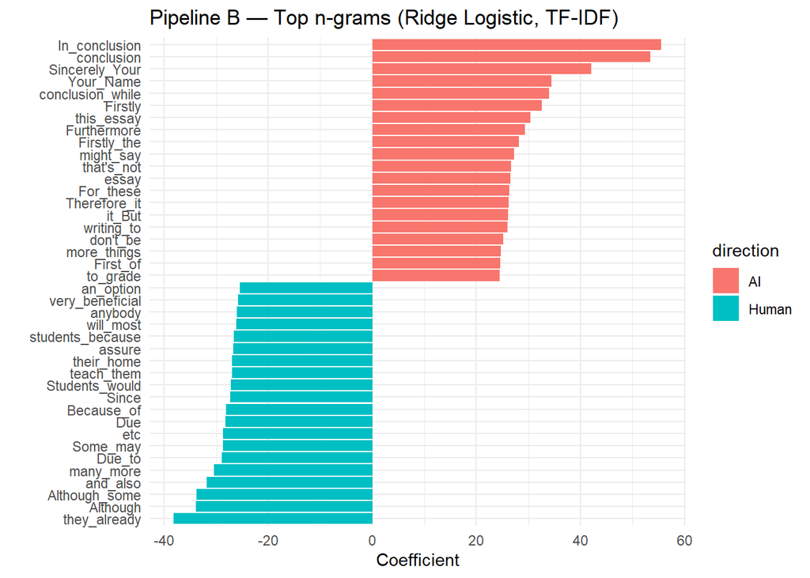

```r
load(here::here("ridge.RData"))
library(ggplot2)

ggplot(coef_top_B, aes(x = reorder(term, coef), y = coef, fill = direction)) +
  geom_col() +
  coord_flip() +
  theme_minimal() +
  labs(
    title = "Pipeline B — Top n-grams (Ridge Logistic, TF-IDF)",
    x = "", y = "Coefficient"
  )
```

## 3.3 Pipeline C — TF‑IDF + SVD + AFD (LDA) + Naive Bayes (CV)

Réduction de dimension via **SVD** sur TF‑IDF, puis **AFD/LDA** et **Naive Bayes** dans l’espace.

Nous utilisons une régression logistique bayésienne entraînée sur des features TF-IDF réduites par SVD. Les paramètres sont estimés par MCMC (Monte Carlo par chaîne de Markov) via **stan_glm**.

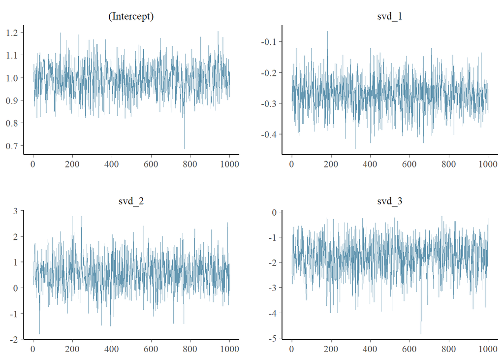

```r
load(normalizePath(here::here("mcmc_results.RData")))  # doit contenir: fit_mcmc, prob_mcmc
bayesplot::mcmc_trace(as.matrix(fit_mcmc),
                      pars = colnames(as.matrix(fit_mcmc))[1:4])
```

La méthode MCMC permet d’obtenir une estimation plus fidèle de la distribution a posteriori contrairement à l’inférence variationnelle qui introduit une approximation supplémentaire.

## 3.4 Évaluation Inter-Dataset (Real test)

Apprentissage sur DAIGT et évaluation sur LLM Detect pour mesurer la robustesse “réaliste”.  
Pour réduire le temps d’exécution, l’évaluation est faite sur un **sous‑échantillon équilibré**.

# 4 Chargement des résultats

> **Important :** ce rapport ne relance pas l’entraînement (trop long).  
> Il charge les fichiers produits par le script R :  
> `model_comparison.csv`, `real_test.RData`, `afd_space.RData`, `mcmc_results.RData`.

```r
# chemins robustes (Windows)
results_summary <- readr::read_csv(normalizePath(here::here("model_comparison.csv")))

load(normalizePath(here::here("real_test.RData")))  # doit contenir: probR, test_real_sub
load(normalizePath(here::here("afd_space.RData")))  # doit contenir: ld_space
```

# 5 Résultats

## 5.1 Tableau comparatif

```r
knitr::kable(results_summary, digits = 3, caption = "Comparaison des pipelines (CV + Real test).")
```

Comparaison des pipelines (CV + Real test).

| Model | Accuracy | F1 | ROC_AUC | Brier |
| --- | --- | --- | --- | --- |
| Stylometry + AFD + Naive Bayes (CV) | 0.912 | 0.911 | 0.970 | 0.065 |
| TF-IDF + Ridge Logistic (CV) | 0.996 | 0.996 | 0.999 | 0.004 |
| TF-IDF + SVD + AFD + Naive Bayes (CV) | 0.982 | 0.982 | 0.997 | 0.015 |
| Real Test (DAIGT → LLM) [fast] | 0.999 | 1.000 | 0.999 | 0.001 |

## 5.2 Graphique comparatif (barplot)

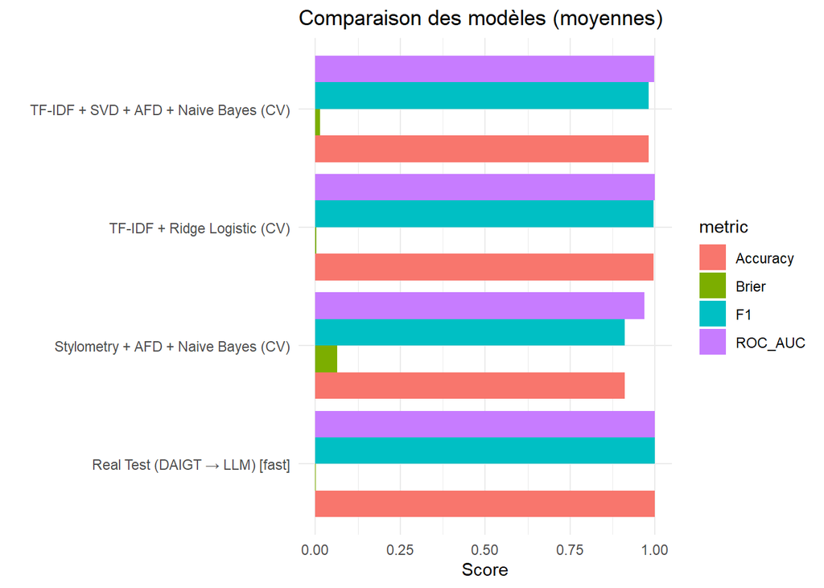

```r
results_long <- tidyr::pivot_longer(results_summary, cols = -Model,
                                   names_to = "metric", values_to = "value")

ggplot(results_long, aes(Model, value, fill = metric)) +
  geom_col(position = "dodge") +
  coord_flip() +
  theme_minimal() +
  labs(title = "Comparaison des modèles (moyennes)", x = "", y = "Score")
```

**Interprétation.**  
On obtient de très bons résultats. Les modèles TF-IDF permettent une classification quasi parfaite, tandis que la réduction discriminante diminue légèrement les performances mais permet une inférence bayésienne interprétable dans un espace de faible dimension.

## 5.3 ROC (Real test)

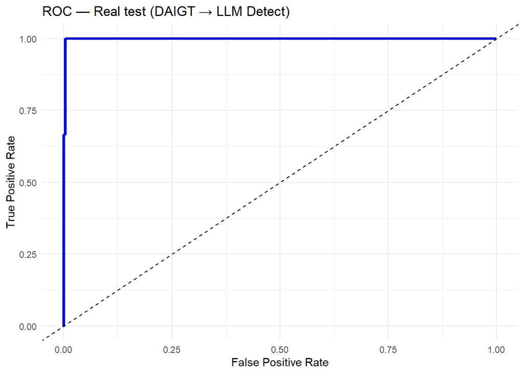

```r
roc_obj <- pROC::roc(
  response = test_real_sub$label,
  predictor = probR,
  levels = c("human", "ai"),
  quiet = TRUE
)

roc_df <- data.frame(
  tpr = roc_obj$sensitivities,
  fpr = 1 - roc_obj$specificities
)

ggplot(roc_df, aes(fpr, tpr)) +
  geom_line(linewidth = 1.2, color = "blue") +
  geom_abline(linetype = "dashed") +
  theme_minimal() +
  labs(
    title = "ROC — Real test (DAIGT → LLM Detect)",
    x = "False Positive Rate",
    y = "True Positive Rate"
  )
```

**Interprétation.**  
La courbe ROC mesure la capacité de discrimination indépendamment du seuil.  
Une courbe proche du coin supérieur gauche indique une séparation forte entre classes.

## 5.4 Calibration (Real test)

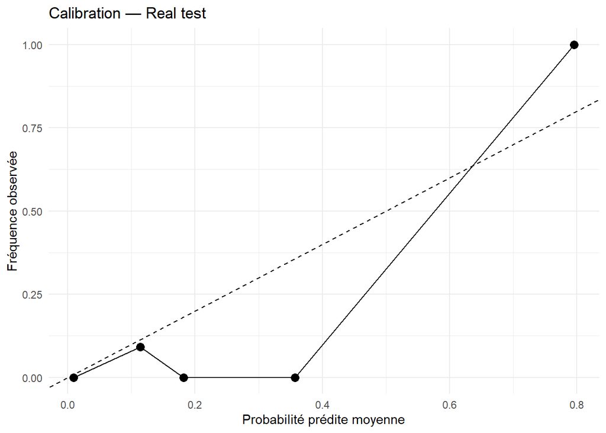

```r
calib_df <- data.frame(
  y = ifelse(test_real_sub$label == "ai", 1, 0),
  prob = probR
)

calib_df$bin <- cut(calib_df$prob, breaks = 10)

calib_summary <- calib_df %>%
  dplyr::group_by(bin) %>%
  dplyr::summarise(
    mean_prob = mean(prob),
    obs_freq  = mean(y),
    .groups = "drop"
  )

ggplot(calib_summary, aes(mean_prob, obs_freq)) +
  geom_point(size = 3) +
  geom_line() +
  geom_abline(linetype = "dashed") +
  theme_minimal() +
  labs(
    title = "Calibration — Real test",
    x = "Probabilité prédite moyenne",
    y = "Fréquence observée"
  )
```

**Interprétation.**  
Le diagramme de calibration vérifie si les probabilités prédites sont fiables (proches de la diagonale).

## 5.5 Visualisation AFD (LD1)

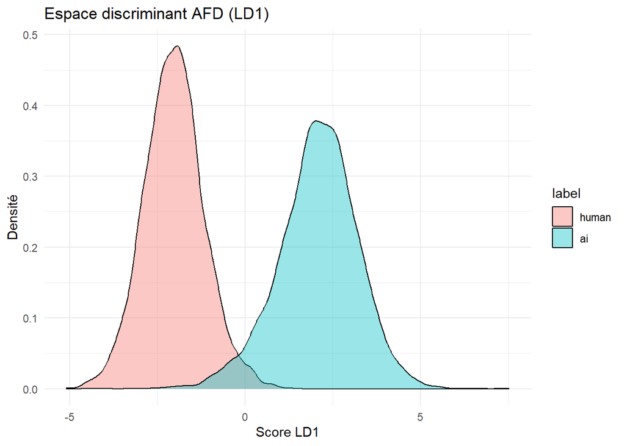

```r
ggplot(ld_space, aes(LD1, fill = label)) +
  geom_density(alpha = 0.4) +
  theme_minimal() +
  labs(
    title = "Espace discriminant AFD (LD1)",
    x = "Score LD1",
    y = "Densité"
  )
```

**Remarque.**  
Avec deux classes, LDA/AFD produit au maximum un seul axe discriminant (LD1).

# 6 Discussion

- Les approches **TF‑IDF** atteignent les meilleures performances : les n‑grams capturent des signatures lexicales fortes.
- La **stylométrie** fournit un baseline robuste mais moins performant.
- La réduction **SVD + AFD** compresse l’information (interprétabilité) avec une légère perte de performance.
- Le **test OOD** (DAIGT → LLM Detect) permet d’évaluer une généralisation plus réaliste.

Limites et pistes : - évaluer par **prompt_id**, - tester sur de nouveaux LLMs / paraphrases, - calibrer via Platt/Isotonic sur un set de validation dédié.

# 7 Conclusion

Le pipeline **TF‑IDF + Ridge Logistic** fournit une détection très performante tout en restant simple et rapide.  
La combinaison **SVD + AFD** améliore l’interprétabilité en gardant une performance élevée.  
L’évaluation inter‑dataset suggère une bonne robustesse (sur sous‑échantillon).

# 8 Références

- Hastie, Tibshirani, Friedman — *The Elements of Statistical Learning*
- Jurafsky & Martin — *Speech and Language Processing*
- Miryam Naddaf - *AI tool detects LLM-generated text in research papers and peer reviews*